# Bayesian modeling and prediction for movies

## Setup

### Load packages

```r
library(ggplot2)
library(dplyr)
library(statsr)
library(BAS)
library(grid)
library(gridExtra)
library(ggcorrplot)
```

### Load data

```r
load("../data/movies.Rdata")
```

## Part 1: Data

The project aims to use Bayesian Inference to predict the audience score of Rotten Tomatoes based on a set of movie features from Rotten Tomatoes and IMDB. The data is consisted of 651 randomly sampled movies released before 2016. Although, the random sampling was used to generate this set of data, the random assignment was not made because there was no experiment being done. Therefore, the sample can only be used to infer generalisation rather than causality between variables.

```r
print(nrow(movies))
```

```
## [1] 651
```

```r
head(movies)
```

```
## # A tibble: 6 x 32
##                  title   title_type       genre runtime mpaa_rating
##                  <chr>       <fctr>      <fctr>   <dbl>      <fctr>
## 1          Filly Brown Feature Film       Drama      80           R
## 2             The Dish Feature Film       Drama     101       PG-13
## 3  Waiting for Guffman Feature Film      Comedy      84           R
## 4 The Age of Innocence Feature Film       Drama     139          PG
## 5          Malevolence Feature Film      Horror      90           R
## 6          Old Partner  Documentary Documentary      78     Unrated
## # ... with 27 more variables: studio <fctr>, thtr_rel_year <dbl>,
## #   thtr_rel_month <dbl>, thtr_rel_day <dbl>, dvd_rel_year <dbl>,
## #   dvd_rel_month <dbl>, dvd_rel_day <dbl>, imdb_rating <dbl>,
## #   imdb_num_votes <int>, critics_rating <fctr>, critics_score <dbl>,
## #   audience_rating <fctr>, audience_score <dbl>, best_pic_nom <fctr>,
## #   best_pic_win <fctr>, best_actor_win <fctr>, best_actress_win <fctr>,
## #   best_dir_win <fctr>, top200_box <fctr>, director <chr>, actor1 <chr>,
## #   actor2 <chr>, actor3 <chr>, actor4 <chr>, actor5 <chr>,
## #   imdb_url <chr>, rt_url <chr>
```

## Part 2: Data manipulation

The five new features were added to the dataset as part of a feature engineering task.

```r
movies <- movies %>%
          mutate(feature_film=as.factor(ifelse(title_type == 'Feature Film', 'yes', 'no'))) %>%
          mutate(drama=as.factor(ifelse(genre == 'Drama', 'yes', 'no'))) %>%
          mutate(mpaa_rating_R=as.factor(ifelse(mpaa_rating == 'R', 'yes', 'no'))) %>%
          mutate(oscar_season=as.factor(ifelse(thtr_rel_month %in% c(10:12), 'yes', 'no'))) %>%
          mutate(summer_season=as.factor(ifelse(thtr_rel_month %in% c(5:8), 'yes', 'no')))
```

## Part 3: Exploratory data analysis

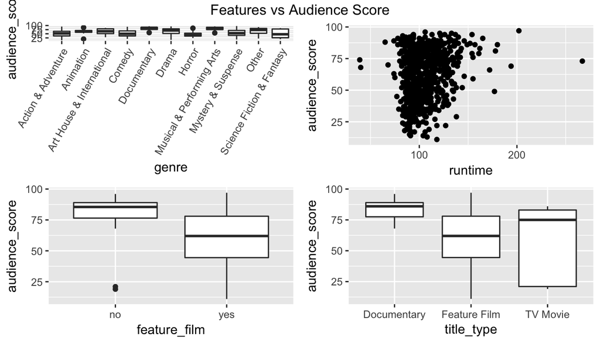

```r
p01 <- ggplot(movies, aes(x = genre, y = audience_score)) + geom_boxplot() + theme(axis.text.x = element_text(angle=60, hjust=1))
p02 <- ggplot(movies, aes(x = runtime, y = audience_score)) + geom_point()
p03 <- ggplot(movies, aes(x = feature_film, y = audience_score)) + geom_boxplot()
p04 <- ggplot(movies, aes(x = title_type, y = audience_score)) + geom_boxplot()
p11 <- ggplot(movies, aes(x = mpaa_rating, y = audience_score)) + geom_boxplot()
p12 <- ggplot(movies, aes(x = mpaa_rating_R, y = audience_score)) + geom_boxplot()
p13 <- ggplot(movies, aes(x = thtr_rel_year, y = audience_score)) + geom_point()
p14 <- ggplot(movies, aes(x = dvd_rel_year, y = audience_score)) + geom_point()
p21 <- ggplot(movies, aes(x = drama, y = audience_score)) + geom_boxplot()
p22 <- ggplot(movies, aes(x = oscar_season, y = audience_score)) + geom_boxplot()
p23 <- ggplot(movies, aes(x = summer_season, y = audience_score)) + geom_boxplot()
p24 <- ggplot(movies, aes(x = imdb_rating, y = audience_score)) + geom_point()
p31 <- ggplot(movies, aes(x = imdb_num_votes, y = audience_score)) + geom_point()
p32 <- ggplot(movies, aes(x = critics_score, y = audience_score)) + geom_point()
p33 <- ggplot(movies, aes(x = best_pic_nom, y = audience_score)) + geom_boxplot()
p34 <- ggplot(movies, aes(x = best_pic_win, y = audience_score)) + geom_boxplot()
p41 <- ggplot(movies, aes(x = best_actor_win, y = audience_score)) + geom_boxplot()
p42 <- ggplot(movies, aes(x = best_actress_win, y = audience_score)) + geom_boxplot()
p43 <- ggplot(movies, aes(x = best_dir_win, y = audience_score)) + geom_boxplot()
p44 <- ggplot(movies, aes(x = top200_box, y = audience_score)) + geom_boxplot()
grid.arrange(p01, p02, p03, p04, ncol=2, top="Features vs Audience Score")
```

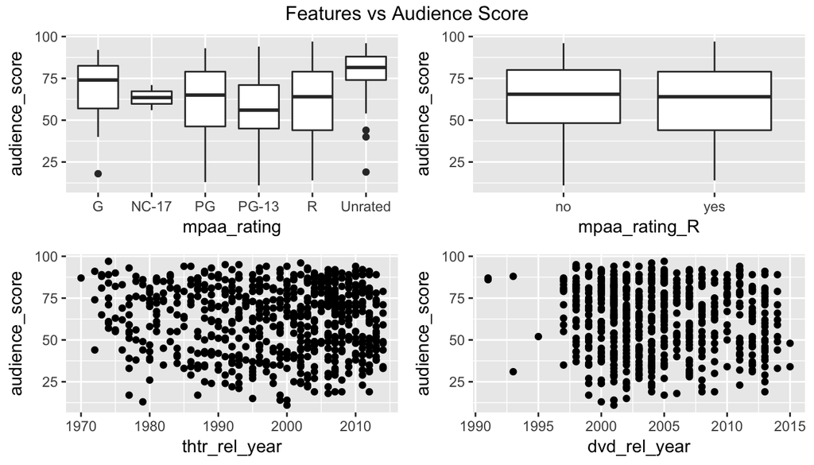

```r
grid.arrange(p11, p12, p13, p14, ncol=2, top="Features vs Audience Score")
```

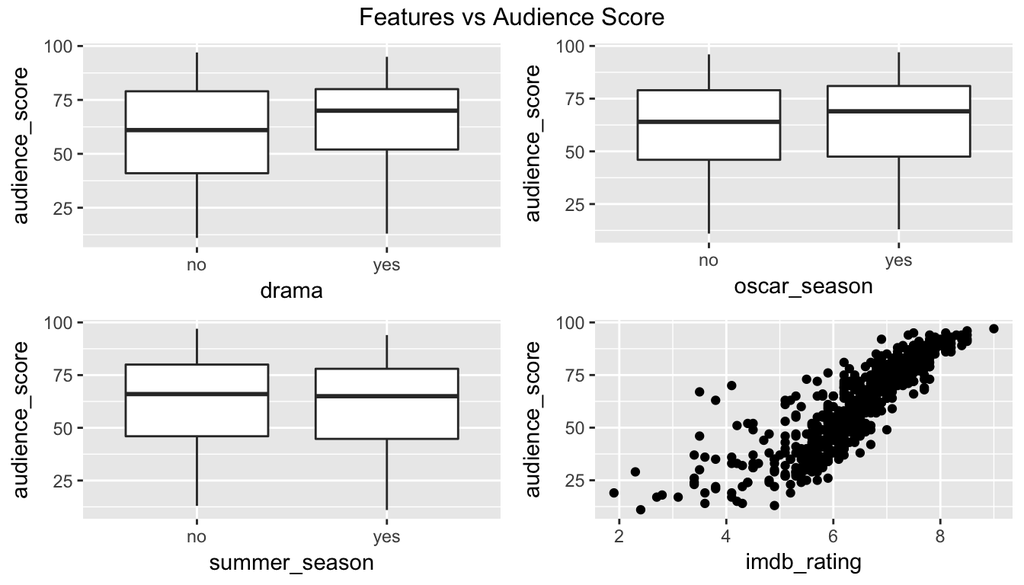

```r
grid.arrange(p21, p22, p23, p24, ncol=2, top="Features vs Audience Score")
```

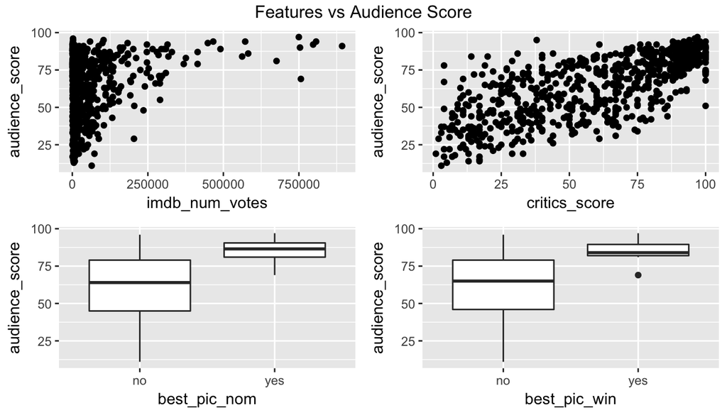

```r
grid.arrange(p31, p32, p33, p34, ncol=2, top="Features vs Audience Score")
```

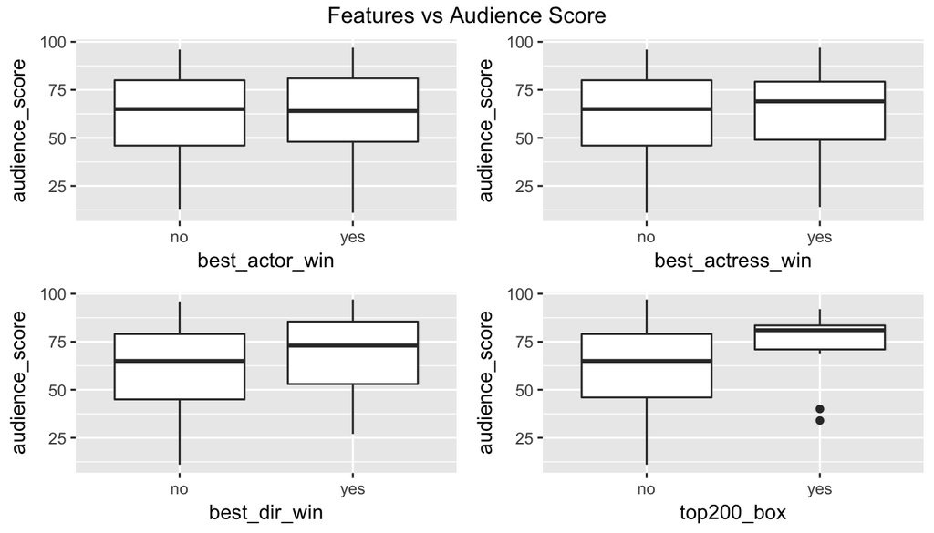

```r
grid.arrange(p41, p42, p43, p44, ncol=2, top="Features vs Audience Score")
```

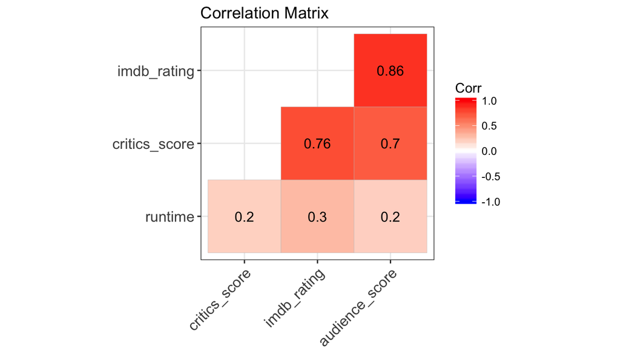

```r
corr_data <- na.omit(movies) %>% select(runtime, imdb_rating, critics_score, audience_score)
corr <- round(cor(corr_data, method='pearson'),3)
ggcorrplot(corr,
           hc.order = TRUE,
           type = "lower",
           lab = TRUE,
           title="Correlation Matrix",
           ggtheme=theme_bw)
```

The correlations were measured using the pearson correlation method. We can see that imdb_rating has the highest correlation of 0.86 followed by critics_score being 0.7. The runtime was included to show that the correlation is only 0.2.

## Part 4: Modeling

### Feature Selection

We selected the numerical predictors and removed the missing rows.

```r
movies_features <- movies %>% select(audience_score,
                 runtime, thtr_rel_year, imdb_rating, imdb_num_votes,
                 best_pic_nom, best_pic_win, critics_score,
                 best_actor_win, best_actress_win, best_dir_win, top200_box,
                 feature_film, drama, mpaa_rating_R, oscar_season, summer_season)
movies_features <- na.omit(movies_features)
```

### Use bas.lm to find the best model

A bayesian model averaging using adaptive sampling for a linear regression model was created using all of the sixteen predictors which results in 2^16 of possible model combinations. Because of the large number of models, we used the Markov Chain Monte Carlo (MCMC) method for the model fitting step and the Zellner-Siow Cauchy distribution for the prior probabilities of the regression coefficients.

```r
set.seed(100000)
baslm = bas.lm(audience_score ~ . -audience_score,
                   data = movies_features,
                   prior = "ZS-null",
                   modelprior = uniform(),
                   method = 'MCMC')
summary(baslm)
```

```
##                     P(B != 0 | Y)  model 1     model 2     model 3
## Intercept              1.00000000   1.0000   1.0000000   1.0000000
## runtime                0.46310272   0.0000   1.0000000   0.0000000
## thtr_rel_year          0.09360352   0.0000   0.0000000   0.0000000
## imdb_rating            0.99999161   1.0000   1.0000000   1.0000000
## imdb_num_votes         0.06088409   0.0000   0.0000000   0.0000000
## best_pic_nomyes        0.13570862   0.0000   0.0000000   0.0000000
## best_pic_winyes        0.04109650   0.0000   0.0000000   0.0000000
## critics_score          0.87762299   1.0000   1.0000000   1.0000000
## best_actor_winyes      0.14554291   0.0000   0.0000000   0.0000000
## best_actress_winyes    0.14383926   0.0000   0.0000000   0.0000000
## best_dir_winyes        0.06897659   0.0000   0.0000000   0.0000000
## top200_boxyes          0.05007782   0.0000   0.0000000   0.0000000
## feature_filmyes        0.06798553   0.0000   0.0000000   0.0000000
## dramayes               0.04530640   0.0000   0.0000000   0.0000000
## mpaa_rating_Ryes       0.20340500   0.0000   0.0000000   1.0000000
## oscar_seasonyes        0.07836685   0.0000   0.0000000   0.0000000
## summer_seasonyes       0.08251724   0.0000   0.0000000   0.0000000
## BF                             NA   1.0000   0.8702806   0.2217602
## PostProbs                      NA   0.1399   0.1223000   0.0308000
## R2                             NA   0.7525   0.7549000   0.7539000
## dim                            NA   3.0000   4.0000000   4.0000000
## logmarg                        NA 443.9495 443.8105657 442.4433468
##                         model 4     model 5
## Intercept             1.0000000   1.0000000
## runtime               0.0000000   1.0000000
## thtr_rel_year         0.0000000   0.0000000
## imdb_rating           1.0000000   1.0000000
## imdb_num_votes        0.0000000   0.0000000
## best_pic_nomyes       0.0000000   0.0000000
## best_pic_winyes       0.0000000   0.0000000
## critics_score         1.0000000   1.0000000
## best_actor_winyes     1.0000000   0.0000000
## best_actress_winyes   0.0000000   0.0000000
## best_dir_winyes       0.0000000   0.0000000
## top200_boxyes         0.0000000   0.0000000
## feature_filmyes       0.0000000   0.0000000
## dramayes              0.0000000   0.0000000
## mpaa_rating_Ryes      0.0000000   1.0000000
## oscar_seasonyes       0.0000000   0.0000000
## summer_seasonyes      0.0000000   0.0000000
## BF                    0.2236679   0.2055844
## PostProbs             0.0288000   0.0281000
## R2                    0.7539000   0.7563000
## dim                   4.0000000   5.0000000
## logmarg             442.4519125 442.3676066
```

### Model Evaluation

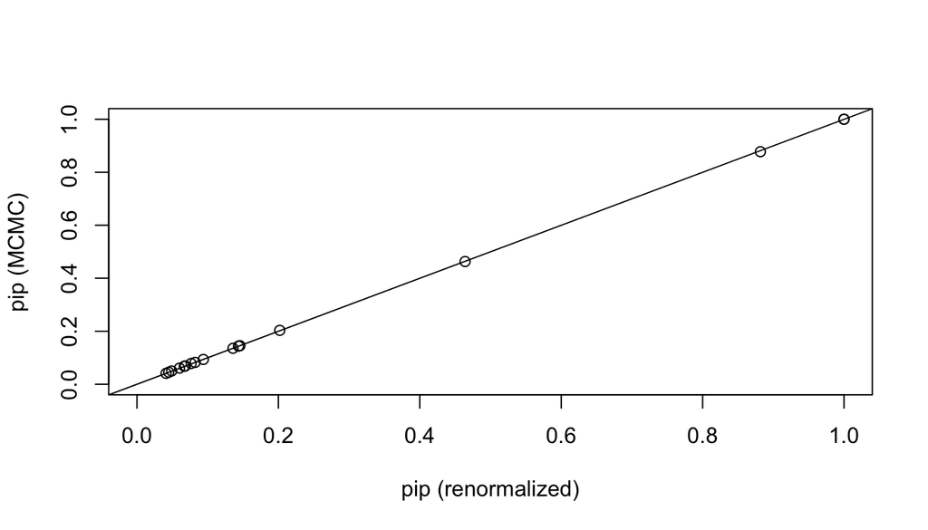

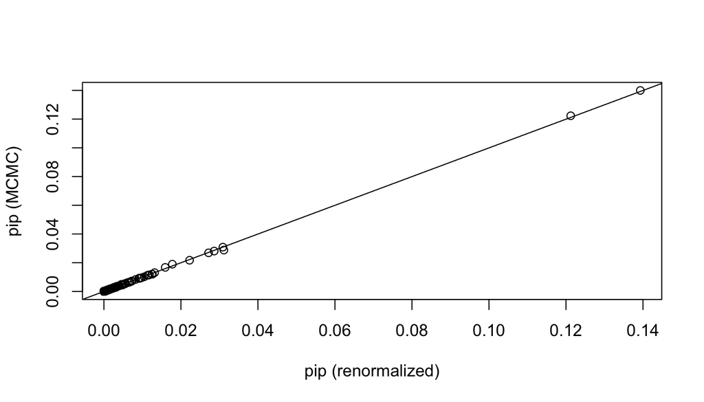

```r
diagnostics(baslm)
```

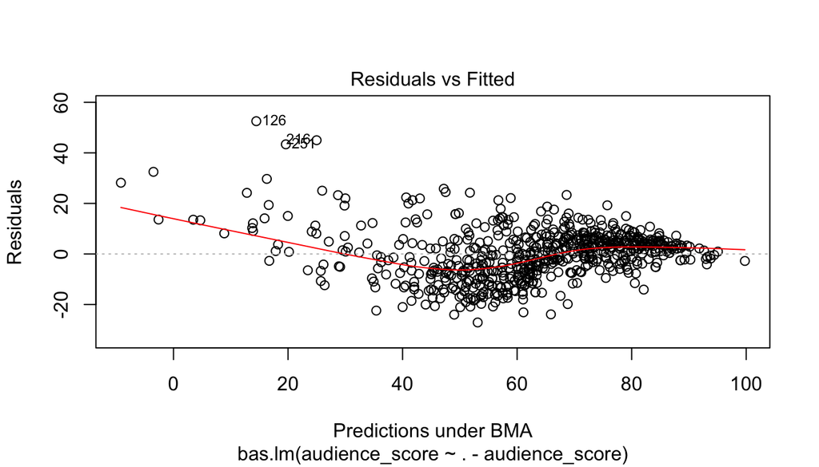

```r
plot(baslm, which = 1, add.smooth = T)
```

The chart shows that the model tends to predict too low for the ratings under a value of 40 and too high for the ratings between 50 and 70. We might need more features to fix this problem. From this graph, it appears that we have three outliers which have been flagged as the points with the three largest residuals.

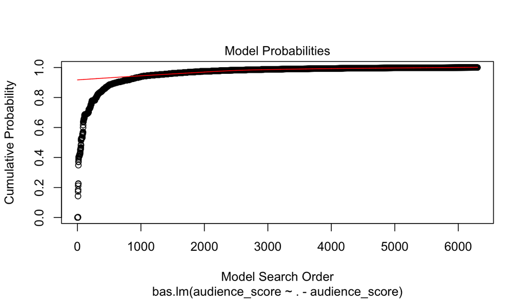

```r
plot(baslm, which = 2, add.smooth = T)
```

The chart shows that the cumulative posterior probability reachs the maximum value (1.0) after approximately 3,000 model combinations.

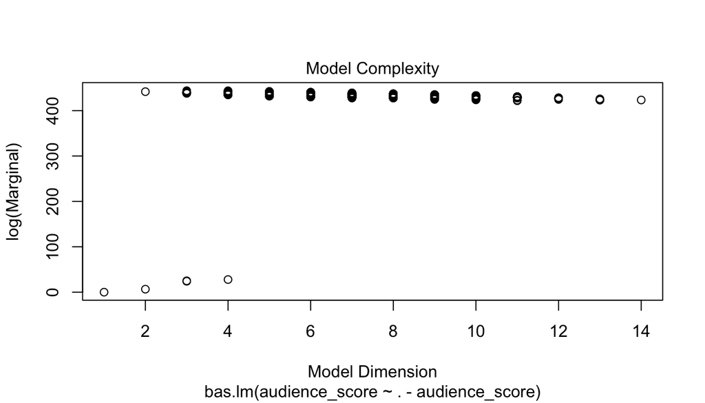

```r
plot(baslm, which = 3, add.smooth = T)
```

The best models with the highest marginal likelihood are in the range of 2 to 4 predictors.

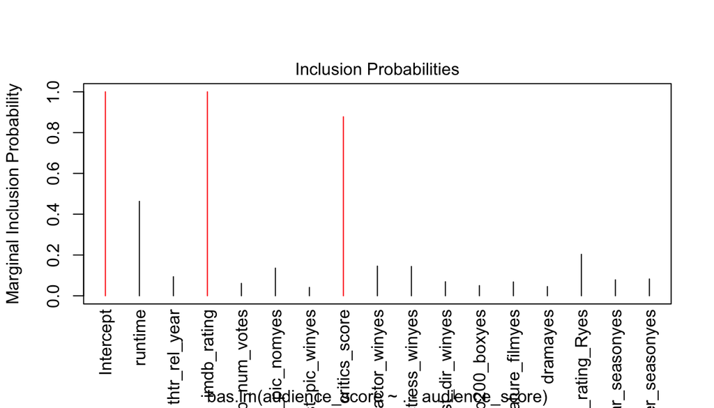

```r
plot(baslm, which = 4, add.smooth = T)
```

This plot of inclusion probabilities confirms our expolatory data analysis that the imdb_rating and critics_score are positively correlated predictors for audience_score.

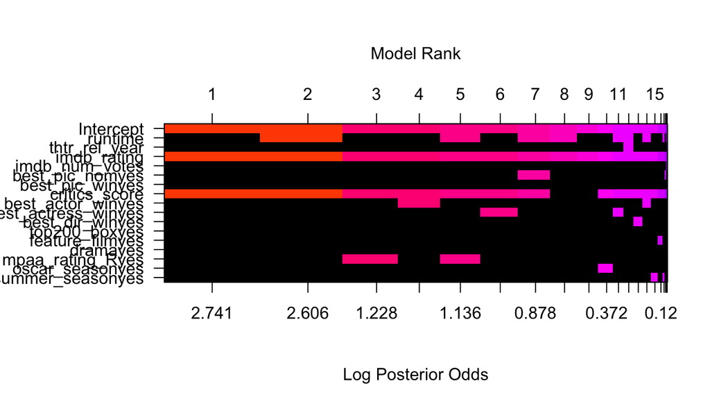

```r
image(baslm, rotate = FALSE)
```

For the top 18 model combinations, almost all best ranking models use imdb_rating and critics_score.

```r
coef(baslm)
```

```
##
##  Marginal Posterior Summaries of Coefficients:
##
##  Using  BMA
##
##  Based on the top  6303 models
##                      post mean   post SD     post p(B != 0)
## Intercept             6.235e+01   3.946e-01   1.000e+00
## runtime              -2.527e-02   3.108e-02   4.631e-01
## thtr_rel_year        -4.704e-03   1.853e-02   9.360e-02
## imdb_rating           1.497e+01   7.414e-01   1.000e+00
## imdb_num_votes        2.218e-07   1.361e-06   6.088e-02
## best_pic_nomyes       5.273e-01   1.598e+00   1.357e-01
## best_pic_winyes      -1.129e-02   8.676e-01   4.110e-02
## critics_score         6.205e-02   3.084e-02   8.776e-01
## best_actor_winyes    -2.875e-01   8.300e-01   1.455e-01
## best_actress_winyes  -3.134e-01   9.107e-01   1.438e-01
## best_dir_winyes      -1.222e-01   6.292e-01   6.898e-02
## top200_boxyes         9.051e-02   7.212e-01   5.008e-02
## feature_filmyes      -1.080e-01   5.736e-01   6.799e-02
## dramayes              1.767e-02   2.003e-01   4.531e-02
## mpaa_rating_Ryes     -3.084e-01   7.071e-01   2.034e-01
## oscar_seasonyes      -8.331e-02   3.839e-01   7.837e-02
## summer_seasonyes      8.872e-02   3.863e-01   8.252e-02
```

The impact of the coefficients of each variable are as follows.

- imdb_rating (with a positive coefficient)
- critics_score (with a positive coefficient)
- runtime (with a negative coefficient)
- mpaa_rating_Ryes (with a negative coefficient)

```r
confint(coef(baslm))
```

```
##                            2.5%        97.5%          beta
## Intercept           61.59091629 6.310992e+01  6.234769e+01
## runtime             -0.08248215 0.000000e+00 -2.527224e-02
## thtr_rel_year       -0.05950749 1.063158e-04 -4.704379e-03
## imdb_rating         13.62127527 1.648808e+01  1.496900e+01
## imdb_num_votes       0.00000000 2.223865e-06  2.218224e-07
## best_pic_nomyes      0.00000000 5.081536e+00  5.272540e-01
## best_pic_winyes      0.00000000 0.000000e+00 -1.128739e-02
## critics_score        0.00000000 1.049659e-01  6.205335e-02
## best_actor_winyes   -2.53236025 0.000000e+00 -2.875299e-01
## best_actress_winyes -2.86007235 0.000000e+00 -3.134265e-01
## best_dir_winyes     -1.62088549 2.704388e-03 -1.222313e-01
## top200_boxyes       -0.18038396 2.471524e-01  9.050998e-02
## feature_filmyes     -1.16725591 0.000000e+00 -1.080277e-01
## dramayes             0.00000000 0.000000e+00  1.767172e-02
## mpaa_rating_Ryes    -2.07306076 0.000000e+00 -3.083970e-01
## oscar_seasonyes     -0.97432197 0.000000e+00 -8.331367e-02
## summer_seasonyes     0.00000000 1.015405e+00  8.872314e-02
## attr(,"Probability")
## [1] 0.95
## attr(,"class")
## [1] "confint.bas"
```

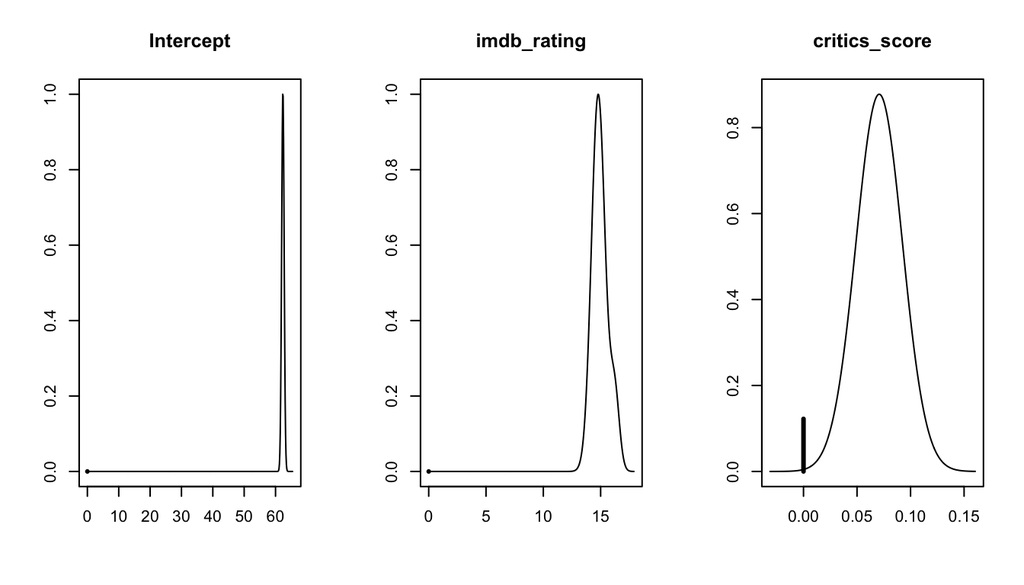

```r
par(mfrow=c(1,3))
plot(coef(baslm), subset=c(1, 4, 8), ask=FALSE)
```

The plot displays the posterior distributions of the regression coefficients. The vertical line at zero on the X axis indicates that the posterior probability of the coefficient is zero. The coefficient of imdb_rating is higher than zero for all the models.

## Part 5: Prediction

```r
new_movie <- data.frame(
  runtime=112,
  thtr_rel_year=2016,
  imdb_rating=8.5,
  imdb_num_votes=70326,
  critics_score=97,
  audience_score=0,
  best_pic_nom=factor("no", levels=c("no", "yes")),
  best_pic_win=factor("no", levels=c("no", "yes")),
  best_actor_win=factor("no", levels=c("no", "yes")),
  best_actress_win=factor("no", levels=c("no", "yes")),
  best_dir_win=factor("no", levels=c("no", "yes")),
  top200_box=factor("no", levels=c("no", "yes")),
  feature_film=factor("no", levels=c("no", "yes")),
  drama=factor("no", levels=c("no", "yes")),
  mpaa_rating_R=factor("no", levels=c("no", "yes")),
  oscar_season=factor("no", levels=c("no", "yes")),
  summer_season=factor("no", levels=c("no", "yes"))
)

predicted_score <- predict(baslm, new_movie, estimator = "BMA", se.fit=TRUE)
ci = qt(0.95, df=predicted_score$se.bma.pred[1]) * mean(predicted_score$se.bma.pred)
data.frame(
  actual=94,
  predicted=predicted_score$fit,
  "2.5"=predicted_score$fit - ci,
  "97.5"=predicted_score$fit + ci
)
```

```
##   actual predicted    X2.5    X97.5
## 1     94  94.92168 76.6017 113.2417
```

## Part 6: Conclusion

In conclusion, our Bayesian regression model was proved to be effective in predicting movie’s audience score based on its attributes. Although, the model does not fit the data very well since it can predict wrongly for a movie with a low audience score; nonetheless, the model can be improved by various methods; for example, we can include genre for modeling to make the prediction more accurate.